# wealth-mobility

Abhraneel Sarma

8/3/2018

If you are missing any of the packages below, use `install.packages("packagename")` to install them. The `import::` syntax requires the `import` package to be installed, and provides a simple way to import specific functions from a package without polluting your entire namespace (unlike `library()`)

```r
library(tidyverse)
library(magrittr)
library(rstan)
rstan_options(auto_write = TRUE)
options(mc.cores = parallel::detectCores())
library(brms)
library(modelr)
library(tidybayes)
library(ggstance)
```

## The Data

The de-identified data consists of the following variables: `parent's wealth quintile`, `child's wealth quintile`, `white (binary; whether the race of the person is white or not)` and `female (binary; whether the person's gender is female or not)`. We do not use female in the subsequent analysis.

```r
df <- read.csv("../data/Data.csv")

df %<>%
  na.omit() %>%
  select(id, white, female, pwealthqn, wealthqn) %>%
  rename(
    quantile = wealthqn,
    pquantile = pwealthqn
  ) %>%
  mutate(
    id = as.factor(id),
    white = as.factor(white),
    female = as.factor(female),
    pquantile = as.factor(pquantile)#,
    #quantile = as.factor(quantile)
  ) %>%
  as.data.frame(.)

head(df)
```

| id | white | female | pquantile | quantile |
| --- | --- | --- | --- | --- |
| 4004 | 1 | 1 | 3 | 5 |
| 4006 | 1 | 1 | 3 | 1 |
| 5003 | 1 | 0 | 2 | 3 |
| 5004 | 1 | 1 | 2 | 2 |
| 5005 | 1 | 0 | 2 | 2 |
| 6004 | 1 | 1 | 5 | 2 |

## Model

Different models can be used to derive the probabilitic. We employ Bayesian models as they are generative and can be used to derive probabilities for for new data. For this example, we use a ordinal logistic regression model and multinomila regression model. We also implement the frequentist version of these models, and calculate the predicted intervals; we use the mean of the point estimates in the visualization.

### Bayesian Ordinal Logistic Regression model

Here, we’ve used an adjacent category model `(family = "acat")` for the ordinal logistic regression. I’ve used ordinal regression because the outcome variable (a child’s wealth quantile) is discrete but ordered; as opposed to a multinomial regression which would have been used had there been no definite order in the discrete outcome variable. There are different families that can be used to model ordinal regressions, such as `cumulative`, `adjacent category` (used here), `stopping ratio`, `continuation ratio`. I do not have a strong basis for choosing this family, and a cumulative logit model or other families for ordinal regression can be used as well.

We use skeptical weak priors $\textrm{N(0,1)}$ in this model for all the parameters.

$$\begin{align}
log(\frac{Pr(y_i = k)}{Pr(y_i = k+1)}) & = \alpha_k - \phi_i \\
\phi_i & = \beta_p P_i + \beta_r[k] R_i\\
\beta_p, \beta_r &\sim \textrm{Normal}(0, 1) \\
\alpha_k & \sim \textrm{Normal}(0,1)
\end{align}$$

```r
load("wealth-mob.models.RData")
#m1.olog <- brm(quantile ~ pquantile + cs(white), data = df, family = "acat", prior=prior(normal(0, 1), class=b), iter = 5000, warmup = 2000, chains = 2, cores = 2)

# m3.olog <- brm(quantile ~ pquantile + white, data = df, family = cumulative("logit"), prior=prior(normal(0, 1), class=b), iter = 5000, warmup = 2000, chains = 2, cores = 2)

summary(m1.olog)
```

```
##  Family: acat
##   Links: mu = logit; disc = identity
## Formula: quantile ~ pquantile + cs(white)
##    Data: df (Number of observations: 1936)
## Samples: 2 chains, each with iter = 5000; warmup = 2000; thin = 1;
##          total post-warmup samples = 6000
##
## Population-Level Effects:
##              Estimate Est.Error l-95% CI u-95% CI Eff.Sample Rhat
## Intercept[1]     0.58      0.09     0.41     0.74       4232 1.00
## Intercept[2]     0.61      0.11     0.40     0.84       3368 1.00
## Intercept[3]     1.30      0.17     0.96     1.63       2897 1.00
## Intercept[4]     1.11      0.28     0.58     1.67       2966 1.00
## pquantile2       0.19      0.06     0.08     0.31       4218 1.00
## pquantile3       0.36      0.06     0.23     0.48       3714 1.00
## pquantile4       0.59      0.07     0.46     0.72       3474 1.00
## pquantile5       0.94      0.08     0.80     1.10       4126 1.00
## white1[1]        0.38      0.13     0.13     0.63       4288 1.00
## white1[2]        0.26      0.15    -0.02     0.55       3578 1.00
## white1[3]        0.94      0.20     0.56     1.32       2861 1.00
## white1[4]        0.51      0.29    -0.05     1.10       2932 1.00
##
## Samples were drawn using sampling(NUTS). For each parameter, Eff.Sample
## is a crude measure of effective sample size, and Rhat is the potential
## scale reduction factor on split chains (at convergence, Rhat = 1).
```

```r
df %>%
  data_grid(pquantile, white) %>%
  add_fitted_draws(m1.olog, re_formula = NA) %>%
  group_by(white, pquantile, .category) %>%
  mean_qi(.value) %>%
  mutate(.value = round(.value, 2))
```

| white | pquantile | .category | .value | .lower | .upper | .width | .point | .interval |
| --- | --- | --- | --- | --- | --- | --- | --- | --- |
| 0 | 1 | 1 | 0.51 | 0.4681583 | 0.5433100 | 0.95 | mean | qi |
| 0 | 1 | 2 | 0.28 | 0.2539551 | 0.3158140 | 0.95 | mean | qi |
| 0 | 1 | 3 | 0.15 | 0.1292779 | 0.1799634 | 0.95 | mean | qi |
| 0 | 1 | 4 | 0.04 | 0.0303927 | 0.0564246 | 0.95 | mean | qi |
| 0 | 1 | 5 | 0.01 | 0.0082185 | 0.0221437 | 0.95 | mean | qi |
| 0 | 2 | 1 | 0.43 | 0.3833416 | 0.4712123 | 0.95 | mean | qi |
| 0 | 2 | 2 | 0.29 | 0.2607812 | 0.3239774 | 0.95 | mean | qi |
| 0 | 2 | 3 | 0.19 | 0.1616847 | 0.2236419 | 0.95 | mean | qi |
| 0 | 2 | 4 | 0.06 | 0.0457006 | 0.0853939 | 0.95 | mean | qi |
| 0 | 2 | 5 | 0.03 | 0.0151782 | 0.0406057 | 0.95 | mean | qi |
| 0 | 3 | 1 | 0.36 | 0.3086051 | 0.4135305 | 0.95 | mean | qi |
| 0 | 3 | 2 | 0.29 | 0.2566593 | 0.3214464 | 0.95 | mean | qi |
| 0 | 3 | 3 | 0.22 | 0.1879103 | 0.2610753 | 0.95 | mean | qi |
| 0 | 3 | 4 | 0.09 | 0.0609408 | 0.1190216 | 0.95 | mean | qi |
| 0 | 3 | 5 | 0.04 | 0.0237447 | 0.0671878 | 0.95 | mean | qi |
| 0 | 4 | 1 | 0.27 | 0.2151248 | 0.3190242 | 0.95 | mean | qi |
| 0 | 4 | 2 | 0.27 | 0.2329223 | 0.3029986 | 0.95 | mean | qi |
| 0 | 4 | 3 | 0.26 | 0.2218055 | 0.3006478 | 0.95 | mean | qi |
| 0 | 4 | 4 | 0.13 | 0.0917009 | 0.1722857 | 0.95 | mean | qi |
| 0 | 4 | 5 | 0.08 | 0.0442270 | 0.1223701 | 0.95 | mean | qi |
| 0 | 5 | 1 | 0.14 | 0.1015137 | 0.1889092 | 0.95 | mean | qi |
| 0 | 5 | 2 | 0.20 | 0.1643656 | 0.2461202 | 0.95 | mean | qi |
| 0 | 5 | 3 | 0.28 | 0.2388992 | 0.3281642 | 0.95 | mean | qi |
| 0 | 5 | 4 | 0.20 | 0.1469239 | 0.2581668 | 0.95 | mean | qi |
| 0 | 5 | 5 | 0.17 | 0.1030199 | 0.2571482 | 0.95 | mean | qi |
| 1 | 1 | 1 | 0.33 | 0.2810429 | 0.3818417 | 0.95 | mean | qi |
| 1 | 1 | 2 | 0.27 | 0.2397318 | 0.3040217 | 0.95 | mean | qi |
| 1 | 1 | 3 | 0.19 | 0.1657914 | 0.2160185 | 0.95 | mean | qi |
| 1 | 1 | 4 | 0.13 | 0.1089245 | 0.1603697 | 0.95 | mean | qi |
| 1 | 1 | 5 | 0.07 | 0.0540031 | 0.0967035 | 0.95 | mean | qi |
| 1 | 2 | 1 | 0.25 | 0.2079388 | 0.2879932 | 0.95 | mean | qi |
| 1 | 2 | 2 | 0.25 | 0.2160246 | 0.2768730 | 0.95 | mean | qi |
| 1 | 2 | 3 | 0.21 | 0.1851817 | 0.2352034 | 0.95 | mean | qi |
| 1 | 2 | 4 | 0.18 | 0.1522926 | 0.2055472 | 0.95 | mean | qi |
| 1 | 2 | 5 | 0.12 | 0.0935640 | 0.1479695 | 0.95 | mean | qi |
| 1 | 3 | 1 | 0.18 | 0.1508978 | 0.2214872 | 0.95 | mean | qi |
| 1 | 3 | 2 | 0.22 | 0.1862628 | 0.2458743 | 0.95 | mean | qi |
| 1 | 3 | 3 | 0.22 | 0.1908665 | 0.2413852 | 0.95 | mean | qi |
| 1 | 3 | 4 | 0.21 | 0.1866652 | 0.2431919 | 0.95 | mean | qi |
| 1 | 3 | 5 | 0.17 | 0.1371700 | 0.2049429 | 0.95 | mean | qi |
| 1 | 4 | 1 | 0.11 | 0.0858082 | 0.1404818 | 0.95 | mean | qi |
| 1 | 4 | 2 | 0.16 | 0.1387546 | 0.1917006 | 0.95 | mean | qi |
| 1 | 4 | 3 | 0.21 | 0.1820375 | 0.2321305 | 0.95 | mean | qi |
| 1 | 4 | 4 | 0.26 | 0.2302401 | 0.2904642 | 0.95 | mean | qi |
| 1 | 4 | 5 | 0.26 | 0.2174430 | 0.3005233 | 0.95 | mean | qi |
| 1 | 5 | 1 | 0.04 | 0.0299776 | 0.0597054 | 0.95 | mean | qi |
| 1 | 5 | 2 | 0.09 | 0.0703899 | 0.1123545 | 0.95 | mean | qi |
| 1 | 5 | 3 | 0.16 | 0.1386150 | 0.1870277 | 0.95 | mean | qi |
| 1 | 5 | 4 | 0.29 | 0.2603896 | 0.3229142 | 0.95 | mean | qi |
| 1 | 5 | 5 | 0.41 | 0.3634594 | 0.4638399 | 0.95 | mean | qi |

### Bayesian Multinomial Regression model

Here, we’ve implemented a multinomial regression. This model doesn’t describe the data as well as the ordinal logistic regression model, as it discards the ordered assumption of the categories. However, the results are similar to the ordered logistic model.

```r
#m2.multinom <- brm(quantile ~ pquantile + white, data = df, family = "categorical", iter = 5000, chains = 2, cores = 2)

summary(m2.multinom)
```

```
##  Family: categorical
##   Links: mu2 = logit; mu3 = logit; mu4 = logit; mu5 = logit
## Formula: quantile ~ pquantile + white
##    Data: df (Number of observations: 1936)
## Samples: 2 chains, each with iter = 5000; warmup = 2500; thin = 1;
##          total post-warmup samples = 5000
##
## Population-Level Effects:
##                Estimate Est.Error l-95% CI u-95% CI Eff.Sample Rhat
## mu2_Intercept     -0.62      0.10    -0.82    -0.42       7036 1.00
## mu3_Intercept     -1.25      0.12    -1.49    -1.02       7519 1.00
## mu4_Intercept     -2.59      0.20    -2.99    -2.21       5872 1.00
## mu5_Intercept     -3.46      0.28    -4.03    -2.94       5075 1.00
## mu2_pquantile2     0.34      0.16     0.03     0.64       4667 1.00
## mu2_pquantile3     0.37      0.21    -0.05     0.76       4482 1.00
## mu2_pquantile4     0.38      0.27    -0.14     0.93       3928 1.00
## mu2_pquantile5     0.17      0.38    -0.58     0.91       3780 1.00
## mu2_white1         0.48      0.15     0.19     0.76       4566 1.00
## mu3_pquantile2     0.58      0.19     0.21     0.94       5197 1.00
## mu3_pquantile3     0.84      0.23     0.39     1.27       4770 1.00
## mu3_pquantile4     1.13      0.27     0.62     1.67       3546 1.00
## mu3_pquantile5     1.22      0.34     0.56     1.89       3600 1.00
## mu3_white1         0.69      0.17     0.36     1.01       4897 1.00
## mu4_pquantile2     0.66      0.26     0.15     1.18       3833 1.00
## mu4_pquantile3     1.37      0.28     0.83     1.92       3884 1.00
## mu4_pquantile4     1.99      0.30     1.42     2.61       3046 1.00
## mu4_pquantile5     2.77      0.35     2.09     3.46       3193 1.00
## mu4_white1         1.44      0.22     1.01     1.87       4685 1.00
## mu5_pquantile2     0.54      0.30    -0.05     1.16       4466 1.00
## mu5_pquantile3     1.04      0.31     0.43     1.65       3924 1.00
## mu5_pquantile4     1.92      0.33     1.29     2.58       3623 1.00
## mu5_pquantile5     2.99      0.37     2.30     3.74       3122 1.00
## mu5_white1         2.31      0.30     1.75     2.90       4813 1.00
##
## Samples were drawn using sampling(NUTS). For each parameter, Eff.Sample
## is a crude measure of effective sample size, and Rhat is the potential
## scale reduction factor on split chains (at convergence, Rhat = 1).
```

```r
df %>%
  data_grid(white, pquantile) %>%
  add_fitted_draws(m2.multinom, re_formula = NA) %>%
  group_by(white, pquantile, .category) %>%
  mean_qi(.value) %>%
  mutate(.value = round(.value, 2))
```

| white | pquantile | .category | .value | .lower | .upper | .width | .point | .interval |
| --- | --- | --- | --- | --- | --- | --- | --- | --- |
| 0 | 1 | 1 | 0.52 | 0.4756638 | 0.5594104 | 0.95 | mean | qi |
| 0 | 1 | 2 | 0.28 | 0.2421448 | 0.3158355 | 0.95 | mean | qi |
| 0 | 1 | 3 | 0.15 | 0.1210947 | 0.1781901 | 0.95 | mean | qi |
| 0 | 1 | 4 | 0.04 | 0.0264509 | 0.0551731 | 0.95 | mean | qi |
| 0 | 1 | 5 | 0.02 | 0.0092892 | 0.0269439 | 0.95 | mean | qi |
| 0 | 2 | 1 | 0.40 | 0.3494637 | 0.4613902 | 0.95 | mean | qi |
| 0 | 2 | 2 | 0.31 | 0.2578886 | 0.3586133 | 0.95 | mean | qi |
| 0 | 2 | 3 | 0.21 | 0.1639158 | 0.2532623 | 0.95 | mean | qi |
| 0 | 2 | 4 | 0.06 | 0.0391523 | 0.0853689 | 0.95 | mean | qi |
| 0 | 2 | 5 | 0.02 | 0.0116978 | 0.0372825 | 0.95 | mean | qi |
| 0 | 3 | 1 | 0.35 | 0.2783311 | 0.4301733 | 0.95 | mean | qi |
| 0 | 3 | 2 | 0.28 | 0.2099631 | 0.3451315 | 0.95 | mean | qi |
| 0 | 3 | 3 | 0.23 | 0.1743281 | 0.3006891 | 0.95 | mean | qi |
| 0 | 3 | 4 | 0.11 | 0.0679937 | 0.1537584 | 0.95 | mean | qi |
| 0 | 3 | 5 | 0.03 | 0.0167709 | 0.0556931 | 0.95 | mean | qi |
| 0 | 4 | 1 | 0.29 | 0.2065777 | 0.3816728 | 0.95 | mean | qi |
| 0 | 4 | 2 | 0.23 | 0.1608249 | 0.3075012 | 0.95 | mean | qi |
| 0 | 4 | 3 | 0.26 | 0.1845031 | 0.3446885 | 0.95 | mean | qi |
| 0 | 4 | 4 | 0.16 | 0.1030772 | 0.2308310 | 0.95 | mean | qi |
| 0 | 4 | 5 | 0.06 | 0.0332441 | 0.1074874 | 0.95 | mean | qi |
| 0 | 5 | 1 | 0.23 | 0.1395785 | 0.3358434 | 0.95 | mean | qi |
| 0 | 5 | 2 | 0.15 | 0.0841697 | 0.2211393 | 0.95 | mean | qi |
| 0 | 5 | 3 | 0.22 | 0.1428269 | 0.3113168 | 0.95 | mean | qi |
| 0 | 5 | 4 | 0.27 | 0.1783494 | 0.3712121 | 0.95 | mean | qi |
| 0 | 5 | 5 | 0.14 | 0.0775288 | 0.2277952 | 0.95 | mean | qi |
| 1 | 1 | 1 | 0.32 | 0.2701870 | 0.3800605 | 0.95 | mean | qi |
| 1 | 1 | 2 | 0.28 | 0.2326814 | 0.3381816 | 0.95 | mean | qi |
| 1 | 1 | 3 | 0.19 | 0.1423107 | 0.2338482 | 0.95 | mean | qi |
| 1 | 1 | 4 | 0.10 | 0.0685316 | 0.1473523 | 0.95 | mean | qi |
| 1 | 1 | 5 | 0.10 | 0.0660127 | 0.1519648 | 0.95 | mean | qi |
| 1 | 2 | 1 | 0.23 | 0.1842169 | 0.2733774 | 0.95 | mean | qi |
| 1 | 2 | 2 | 0.28 | 0.2298136 | 0.3299767 | 0.95 | mean | qi |
| 1 | 2 | 3 | 0.23 | 0.1860753 | 0.2800747 | 0.95 | mean | qi |
| 1 | 2 | 4 | 0.14 | 0.1028510 | 0.1828080 | 0.95 | mean | qi |
| 1 | 2 | 5 | 0.12 | 0.0861231 | 0.1679518 | 0.95 | mean | qi |
| 1 | 3 | 1 | 0.17 | 0.1356549 | 0.2190135 | 0.95 | mean | qi |
| 1 | 3 | 2 | 0.22 | 0.1730768 | 0.2695722 | 0.95 | mean | qi |
| 1 | 3 | 3 | 0.23 | 0.1817034 | 0.2816132 | 0.95 | mean | qi |
| 1 | 3 | 4 | 0.22 | 0.1708129 | 0.2701576 | 0.95 | mean | qi |
| 1 | 3 | 5 | 0.16 | 0.1158766 | 0.2021212 | 0.95 | mean | qi |
| 1 | 4 | 1 | 0.12 | 0.0830008 | 0.1594365 | 0.95 | mean | qi |
| 1 | 4 | 2 | 0.15 | 0.1100813 | 0.1931613 | 0.95 | mean | qi |
| 1 | 4 | 3 | 0.21 | 0.1617187 | 0.2570993 | 0.95 | mean | qi |
| 1 | 4 | 4 | 0.27 | 0.2224504 | 0.3247896 | 0.95 | mean | qi |
| 1 | 4 | 5 | 0.25 | 0.2028335 | 0.3060091 | 0.95 | mean | qi |
| 1 | 5 | 1 | 0.07 | 0.0398786 | 0.1004138 | 0.95 | mean | qi |
| 1 | 5 | 2 | 0.07 | 0.0413843 | 0.1030883 | 0.95 | mean | qi |
| 1 | 5 | 3 | 0.13 | 0.0889140 | 0.1700685 | 0.95 | mean | qi |
| 1 | 5 | 4 | 0.33 | 0.2737090 | 0.3882976 | 0.95 | mean | qi |
| 1 | 5 | 5 | 0.41 | 0.3480211 | 0.4696877 | 0.95 | mean | qi |

#### Model comparison

Now we compare the two models by drawing samples from each

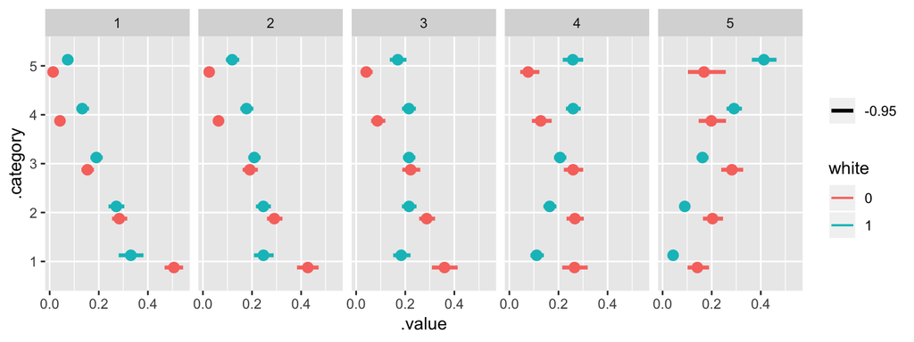

```r
df %>%
  data_grid(pquantile, white) %>%
  add_fitted_draws(m1.olog, re_formula = NA) %>%
  group_by(.category, pquantile, white) %>%
  ggplot(aes(y = .category, x = .value, color = white))+
  stat_pointintervalh(.width = 0.95, position = position_dodgev(height = 0.5), show.legend = TRUE) +
  facet_grid(.~pquantile)
```

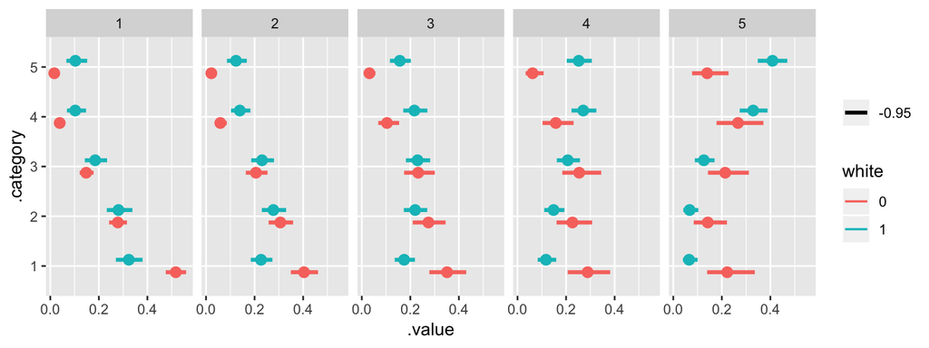

```r
df %>%
  data_grid(pquantile, white) %>%
  add_fitted_draws(m2.multinom, re_formula = NA) %>%
  group_by(white, pquantile, .category) %>%
  ggplot(aes(y = .category, x = .value, color = white))+
  stat_pointintervalh(.width = 0.95, position = position_dodgev(height = 0.5), show.legend = TRUE) +
  facet_grid(.~pquantile)
```

#### Frequentist models

We implement the frequentist analog of the Bayesian models to see if the results are similar. Under our choice of weakly informed priors, we can see the derived point estimates are similar.

```r
library(ordinal)
df %<>%
  mutate(c_quantile = as.factor(quantile))

m1.olog.lm <- clm(c_quantile ~ pquantile + white, data = df, link = "logit")

df %>%
  data_grid(pquantile, white) %>%
  predict(m1.olog.lm, ., type="prob") %>%
  as.data.frame(.) %>%
  mutate(
    pquantile = rep(1:(nrow(.)/2), each = 2),
    white = (0:(nrow(.)-1) %% 2)
  ) %>%
  gather(quantile, .value, 1:5) %>%
  separate(col = quantile, into = c('delete', 'c_quantile'), sep = 't.') %>%
  select(-delete) %>%
  mutate(.value = round(.value, 2)) %>%
  arrange(desc(pquantile), desc(c_quantile), desc(white))
```

| pquantile | white | c_quantile | .value |
| --- | --- | --- | --- |
| 5 | 1 | 5 | 0.42 |
| 5 | 0 | 5 | 0.22 |
| 5 | 1 | 4 | 0.28 |
| 5 | 0 | 4 | 0.26 |
| 5 | 1 | 3 | 0.17 |
| 5 | 0 | 3 | 0.25 |
| 5 | 1 | 2 | 0.09 |
| 5 | 0 | 2 | 0.17 |
| 5 | 1 | 1 | 0.04 |
| 5 | 0 | 1 | 0.11 |
| 4 | 1 | 5 | 0.24 |
| 4 | 0 | 5 | 0.11 |
| 4 | 1 | 4 | 0.27 |
| 4 | 0 | 4 | 0.17 |
| 4 | 1 | 3 | 0.24 |
| 4 | 0 | 3 | 0.25 |
| 4 | 1 | 2 | 0.16 |
| 4 | 0 | 2 | 0.26 |
| 4 | 1 | 1 | 0.09 |
| 4 | 0 | 1 | 0.22 |
| 3 | 1 | 5 | 0.15 |
| 3 | 0 | 5 | 0.06 |
| 3 | 1 | 4 | 0.21 |
| 3 | 0 | 4 | 0.11 |
| 3 | 1 | 3 | 0.26 |
| 3 | 0 | 3 | 0.20 |
| 3 | 1 | 2 | 0.23 |
| 3 | 0 | 2 | 0.29 |
| 3 | 1 | 1 | 0.16 |
| 3 | 0 | 1 | 0.34 |
| 2 | 1 | 5 | 0.10 |
| 2 | 0 | 5 | 0.04 |
| 2 | 1 | 4 | 0.17 |
| 2 | 0 | 4 | 0.08 |
| 2 | 1 | 3 | 0.24 |
| 2 | 0 | 3 | 0.16 |
| 2 | 1 | 2 | 0.26 |
| 2 | 0 | 2 | 0.28 |
| 2 | 1 | 1 | 0.22 |
| 2 | 0 | 1 | 0.43 |
| 1 | 1 | 5 | 0.07 |
| 1 | 0 | 5 | 0.03 |
| 1 | 1 | 4 | 0.13 |
| 1 | 0 | 4 | 0.06 |
| 1 | 1 | 3 | 0.22 |
| 1 | 0 | 3 | 0.13 |
| 1 | 1 | 2 | 0.29 |
| 1 | 0 | 2 | 0.26 |
| 1 | 1 | 1 | 0.30 |
| 1 | 0 | 1 | 0.53 |

```r
library(nnet)

m2.multinom.lm <- multinom(quantile ~ pquantile + white, data = df, Hess = TRUE)
summary(m2.multinom.lm)
```

```
## Call:
## multinom(formula = quantile ~ pquantile + white, data = df, Hess = TRUE)
##
## Coefficients:
##   (Intercept) pquantile2 pquantile3 pquantile4 pquantile5    white1
## 2  -0.6177634  0.3405235  0.3683424  0.3804589   0.168502 0.4784698
## 3  -1.2494757  0.5795149  0.8362867  1.1284015   1.204272 0.6898134
## 4  -2.5733457  0.6608880  1.3629416  1.9767226   2.742414 1.4307431
## 5  -3.4228390  0.5329545  1.0307165  1.8974728   2.947985 2.2897198
##
## Std. Errors:
##   (Intercept) pquantile2 pquantile3 pquantile4 pquantile5    white1
## 2  0.09922865  0.1570030  0.2121630  0.2702121  0.3643799 0.1522512
## 3  0.12191408  0.1789489  0.2248938  0.2693013  0.3366949 0.1662115
## 4  0.20034231  0.2561758  0.2754647  0.3014437  0.3415787 0.2195921
## 5  0.28116715  0.3000751  0.3143401  0.3234817  0.3563492 0.2951470
##
## Residual Deviance: 5433.264
## AIC: 5481.264
```

```r
df %>%
  data_grid(pquantile, white) %>%
  predict(m2.multinom.lm, ., "probs") %>%
  as.data.frame(.) %>%
  mutate(
    pquantile = rep(1:(nrow(.)/2), each = 2),
    white = (0:(nrow(.)-1) %% 2)
  ) %>%
  gather(quantile, .value, c(`1`, `2`, `3`, `4`, `5`)) %>%
  mutate(.value = round(.value, 2)) %>%
  arrange(desc(pquantile), desc(quantile), desc(white))
```

| pquantile | white | quantile | .value |
| --- | --- | --- | --- |
| 5 | 1 | 5 | 0.41 |
| 5 | 0 | 5 | 0.14 |
| 5 | 1 | 4 | 0.33 |
| 5 | 0 | 4 | 0.27 |
| 5 | 1 | 3 | 0.13 |
| 5 | 0 | 3 | 0.22 |
| 5 | 1 | 2 | 0.07 |
| 5 | 0 | 2 | 0.15 |
| 5 | 1 | 1 | 0.07 |
| 5 | 0 | 1 | 0.23 |
| 4 | 1 | 5 | 0.25 |
| 4 | 0 | 5 | 0.06 |
| 4 | 1 | 4 | 0.27 |
| 4 | 0 | 4 | 0.16 |
| 4 | 1 | 3 | 0.21 |
| 4 | 0 | 3 | 0.26 |
| 4 | 1 | 2 | 0.15 |
| 4 | 0 | 2 | 0.23 |
| 4 | 1 | 1 | 0.12 |
| 4 | 0 | 1 | 0.29 |
| 3 | 1 | 5 | 0.16 |
| 3 | 0 | 5 | 0.03 |
| 3 | 1 | 4 | 0.22 |
| 3 | 0 | 4 | 0.11 |
| 3 | 1 | 3 | 0.23 |
| 3 | 0 | 3 | 0.23 |
| 3 | 1 | 2 | 0.22 |
| 3 | 0 | 2 | 0.28 |
| 3 | 1 | 1 | 0.17 |
| 3 | 0 | 1 | 0.35 |
| 2 | 1 | 5 | 0.12 |
| 2 | 0 | 5 | 0.02 |
| 2 | 1 | 4 | 0.14 |
| 2 | 0 | 4 | 0.06 |
| 2 | 1 | 3 | 0.23 |
| 2 | 0 | 3 | 0.21 |
| 2 | 1 | 2 | 0.28 |
| 2 | 0 | 2 | 0.31 |
| 2 | 1 | 1 | 0.23 |
| 2 | 0 | 1 | 0.40 |
| 1 | 1 | 5 | 0.10 |
| 1 | 0 | 5 | 0.02 |
| 1 | 1 | 4 | 0.10 |
| 1 | 0 | 4 | 0.04 |
| 1 | 1 | 3 | 0.19 |
| 1 | 0 | 3 | 0.15 |
| 1 | 1 | 2 | 0.28 |
| 1 | 0 | 2 | 0.28 |
| 1 | 1 | 1 | 0.32 |
| 1 | 0 | 1 | 0.52 |